# Projekt

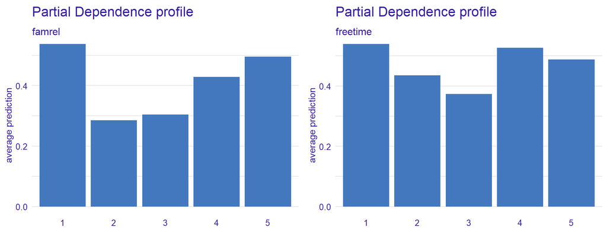

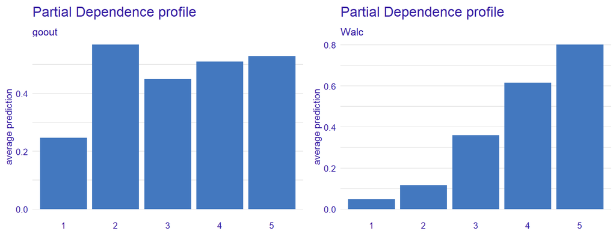

Najwyższą wartość predykjci osiągnieto w przypadku gdy ankietowany mało czasu spędza z przyjaciółmi, jednak w przypadku daleszego ograniczania tego czasu (*goout* = 1) wartość predykcji jest najmnijesza. W związku z tym nie znaleziono uzasadnienia tej sytuacji. Wraz ze wzrostem wartości zmiennej *Walc* odnotowano wzrost wartości zmiennej prognozowanej. Zatem zwiększona częstość spożywania alkoholu podczas weekendu przekłada się na większe prawdopodobieństwo wystąpienia problemu z nadużywaniem alkoholu.

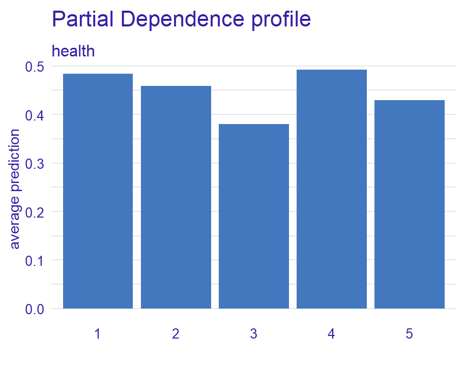

Analizując stan zdrowia ankietowanego nie zauważono wyraźnych zależności. Najniższą wartość zmiennej prognozowanej otrzymano w przypadku określenia w ankiecie stanu zdrowia jako “średni”, natomiast już określenie go jako “bardzo zły” bądź “dobry” znacznie zwiększa wartość prognozy.

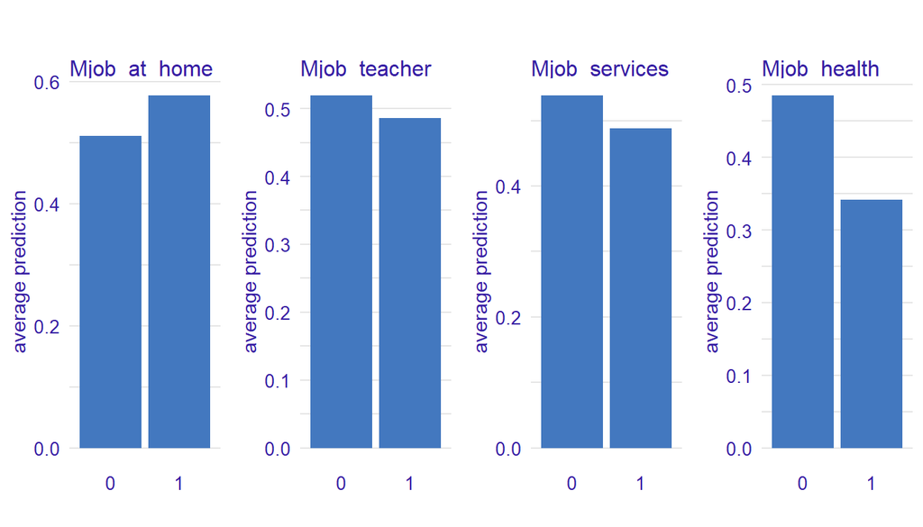

Dla zmiennych *Mjob_teacher*, *Mjob_services* oraz *Mjob_health* wyższe wartości osiągnięto, w przypadku gdy mama wykonuje inną pracę niż wskazaną. Odmienną sytuację zaobserwowano dla zmiennej *Mjob_at_home*, wówczas wyższą wartość otrzymano w przypadku pozytywnej wartości tej zmiennej. Zatem przypadek gdy mama ankietowanego nie pracuje zwiększa się prawdopodobieństwo wystąpienia u niego problemu z nadużywaniem alkoholu.

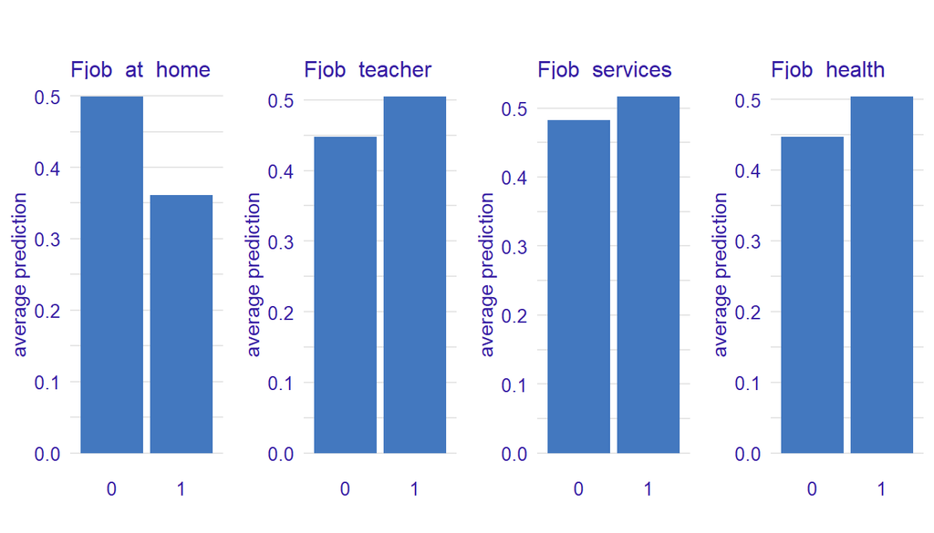

W przypadku gdy tata danego ucznia/studenta nie pracuje wartości predykcji różnią się od tych otrzymanych w sytuacji gdy bez pracy pozostaje jego mama. Wartość zmiennej wynikowej jest bowiem wyższa gdy ojciec jest czynny zawodowo. W pozostałych przypadkach każdy wykonywany zawód (tj. nauczyciel bądź praca w sektorze usług czy też w sektorze medycznym) zwiększa wartość otrzymywanej predykcji.

## Podsumowanie

Celem projektu było stworzenie modelu, który na podstawie informacji dostępnych z ankiet przeprowadzonych wśród uczniów/studentów będzie w stanie wskazać nauczycielom uczniów, którzy mogą potrzebować pomocy.

W tym celu po przeprowadzeniu wstępnej analizy oraz odpowiednim przygotowaniu danych, w tym wykorzystania oversamplingu do zbalansowania zbioru uczącego, zbudowano trzy modele. Wykorzystano następujące metody uczenia maszynowego: lasy losowe, algorytm SVM z jądrem radialnym oraz regresję logistyczną. Najwyższą wartość czułości, którą uznano za najważniejszy wskaźnik jakości modelu otrzymano dla modelu zbudowanego z wykorzystaniem SVM.

Analiza ważności zmiennych dla modelu utworzonego za pomocą lasów losowych wskazała na istotność zmiennej *Walc*. Na kolejnych miejscach znalazły się odpowiednio *goout* oraz *freetime*. Analiza interpretowalności modelu regresji logistycznej pozwoliła na wyłonienie zależności między zmienną *Walc* i zmienną wynikową. Większe spożycie alkoholu podczas weekendu przekłada się bowiem na wzrost wartości predykcji. Zauważono również, że wraz z wiekiem bądź rosnącą liczbą nieobecności w szkole model przywiduje wyższe wartości prognozy. W przypadku większości zmiennych nie znaleziono jednak uzasadnienia w życiu rzeczywistym.